# 전체 팀의 스텟 간 상관분석

전체 팀의 경기 스텟 간 상관을 분석하여 스텟간 관련성을 발견함에 목적이 있다.

## 준비

- 패키지 설치
- 라이브러리 부착
- 데이터 불러오기 - json

```r
# 라이브러리 부착
library(jsonlite)
library(PerformanceAnalytics)
library(corrplot)
```

```r
# 최근 다섯 시즌 전체팀의 경기 데이터를 불러오기
data = fromJSON('AllTeam.json')
```

## 데이터 프레임 생성

- 데이터 프레임 생성
- 변수명 변경
- 불필요한 변수 제거

```r
# 데이터 프레임 생성
data = data.frame(data)
```

```r
# 변수명 확인
colnames(data)
```

1. 'list.Team'

2. 'list.Matchyear'

3. 'list.Matchday'

4. 'list.WinorLose'

5. 'list.Formation'

6. 'list.Possession'

7. 'list.Shots'

8. 'list.Shots_on_Target'

9. 'list.Touches'

10. 'list.Passes'

11. 'list.Tackles'

12. 'list.Clearances'

13. 'list.Corners'

14. 'list.Offsides'

15. 'list.Yellow_cards'

16. 'list.Red_cards'

17. 'list.Fouls_conceded'

18. 'list.num'

```r
# 새로운 변수명 생성
col_list  <- c('Team','Matchyear','Matchday','WinorLose','Formation','Possession','Shots','Shots_on_target','Touches','Passes','Tackles','Clearances','Corners','Offsides','Yellow_cards','Red_cards','Foul_conceded','num')
```

```r
# 새로운 변수명 부여
colnames(data)  <- col_list
```

```r
# 불필요한 변수 제거 : 팀명, 경기년도, 경기일, 승패여부, 포메이션 , 경기식별번호
data  <-  subset(data, select = c(-Team,-Matchyear,-Matchday, -num,-WinorLose, -Formation))
```

```r
# 불필요한 변수 제거 확인
head(data)
```

| Possession | Shots | Shots_on_target | Touches | Passes | Tackles | Clearances | Corners | Offsides | Yellow_cards | Red_cards | Foul_conceded |
| --- | --- | --- | --- | --- | --- | --- | --- | --- | --- | --- | --- |
| 58.4 | 11 | 2 | 747 | 548 | 14 | 16 | 6 | 0 | 3 | 0 | 13 |
| 41.6 | 7 | 3 | 604 | 391 | 24 | 39 | 3 | 0 | 4 | 0 | 13 |
| 52.0 | 11 | 3 | 635 | 433 | 16 | 14 | 4 | 2 | 1 | 1 | 15 |
| 48.0 | 17 | 10 | 616 | 399 | 22 | 29 | 8 | 4 | 3 | 0 | 16 |
| 66.6 | 10 | 5 | 774 | 558 | 14 | 25 | 8 | 4 | 1 | 0 | 7 |
| 33.4 | 11 | 5 | 510 | 286 | 25 | 53 | 2 | 1 | 2 | 0 | 13 |

## 전체 팀 변수 상관관계 분석

- 점유율, 슛, 유효슛, 터치, 패스, 태클, 클리어링, 코너킥, 오프사이드, 옐로카드, 레드카드, 파울 각 변수끼리의 상관관계를 확인

```r
data_cor  <- cor(data)
data_cor
```

|  | Possession | Shots | Shots_on_target | Touches | Passes | Tackles | Clearances | Corners | Offsides | Yellow_cards | Red_cards | Foul_conceded |
| --- | --- | --- | --- | --- | --- | --- | --- | --- | --- | --- | --- | --- |
| Possession | 1.00000000 | 0.56768338 | 0.37763978 | 0.91694544 | 0.90345980 | -0.17778530 | -0.42853715 | 0.470022005 | -0.045999666 | -0.110464860 | -0.08252489 | -0.11354415 |
| Shots | 0.56768338 | 1.00000000 | 0.69357213 | 0.52755132 | 0.49306215 | -0.10694319 | -0.31163620 | 0.567986666 | -0.032109373 | -0.102459374 | -0.09300599 | -0.08040302 |
| Shots_on_target | 0.37763978 | 0.69357213 | 1.00000000 | 0.38652603 | 0.37205917 | -0.04604486 | -0.17505589 | 0.336787775 | 0.022283909 | -0.097066278 | -0.06058621 | -0.03894482 |
| Touches | 0.91694544 | 0.52755132 | 0.38652603 | 1.00000000 | 0.98664889 | -0.10451099 | -0.42591023 | 0.376690159 | -0.024578135 | -0.157397633 | -0.10041782 | -0.21506229 |
| Passes | 0.90345980 | 0.49306215 | 0.37205917 | 0.98664889 | 1.00000000 | -0.16264329 | -0.47453858 | 0.341455037 | -0.033707799 | -0.162262874 | -0.08873718 | -0.21726789 |
| Tackles | -0.17778530 | -0.10694319 | -0.04604486 | -0.10451099 | -0.16264329 | 1.00000000 | 0.08176229 | -0.111631907 | 0.013941827 | 0.044735482 | -0.01835269 | 0.08162845 |
| Clearances | -0.42853715 | -0.31163620 | -0.17505589 | -0.42591023 | -0.47453858 | 0.08176229 | 1.00000000 | -0.289698292 | 0.019174285 | 0.082728775 | 0.02964917 | 0.08177040 |
| Corners | 0.47002201 | 0.56798667 | 0.33678777 | 0.37669016 | 0.34145504 | -0.11163191 | -0.28969829 | 1.000000000 | -0.002133062 | -0.070571948 | -0.04919153 | -0.07552361 |
| Offsides | -0.04599967 | -0.03210937 | 0.02228391 | -0.02457814 | -0.03370780 | 0.01394183 | 0.01917429 | -0.002133062 | 1.000000000 | 0.002551549 | -0.04173961 | -0.05649874 |
| Yellow_cards | -0.11046486 | -0.10245937 | -0.09706628 | -0.15739763 | -0.16226287 | 0.04473548 | 0.08272878 | -0.070571948 | 0.002551549 | 1.000000000 | 0.01057839 | 0.37975681 |
| Red_cards | -0.08252489 | -0.09300599 | -0.06058621 | -0.10041782 | -0.08873718 | -0.01835269 | 0.02964917 | -0.049191529 | -0.041739610 | 0.010578390 | 1.00000000 | 0.03837865 |
| Foul_conceded | -0.11354415 | -0.08040302 | -0.03894482 | -0.21506229 | -0.21726789 | 0.08162845 | 0.08177040 | -0.075523612 | -0.056498739 | 0.379756805 | 0.03837865 | 1.00000000 |

Possession - Shots 0.568 Possession- Shots_on_target 0.377 Possession - Touches 0.917 Possession - Passes 0.903 Possession - Clearances -0.429 Possession - Corners 0.470 Shots - Shots_on_target 0.694 Shots - Touches 0.528 Shots - Passes 0.493 Shots - Clearances -0.311 Shots - Corners 0.567 Shots_on_target - Touches 0.387 Shots_on_target - Passes 0.372 Shots_on_target - Corners 0.336 Touches - Passes 0.987 Touches - Clearances -0.426 Touches - Corners 0.377 Passes - Clearances -0.475 Passes - Corners 0.341 Yellow_cards - Foul_conceded 0.380

## 상관관계 시각화1

- 변수의 상관관계를 다양한 방법으로 시각화
- PerformanceAnalytics 라이브러리 사용
- 대각선은 각 변수의 막대선 그래프를 보여주며 우상단은 변수끼리의 상관관계 수치, 좌하단은 변수 간의 상관 산점도와 선을 나타냄

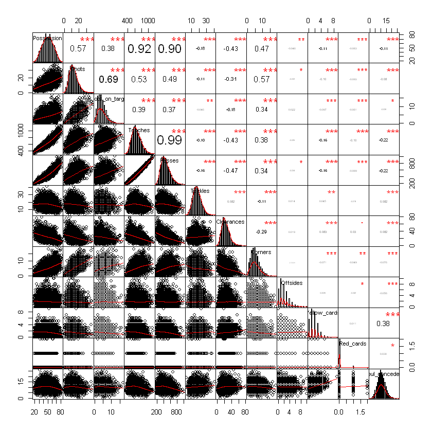

```r
chart.Correlation(data, histogram = TRUE, pch = 19)
```

## 상관관계 시각화2

- 전체팀 변수의 상관관계를 수치와 색을 이용해 시각화하여 유의미한 상관을 찾기 편하게 가공
- corrplot 라이브러리 사용
- -1~1 사이의 수치를 보여주며 절대값 1에 가까울수록 상관이 높음을 의미하고 파래질수록 1, 붉어질수록 -1에 가까워짐

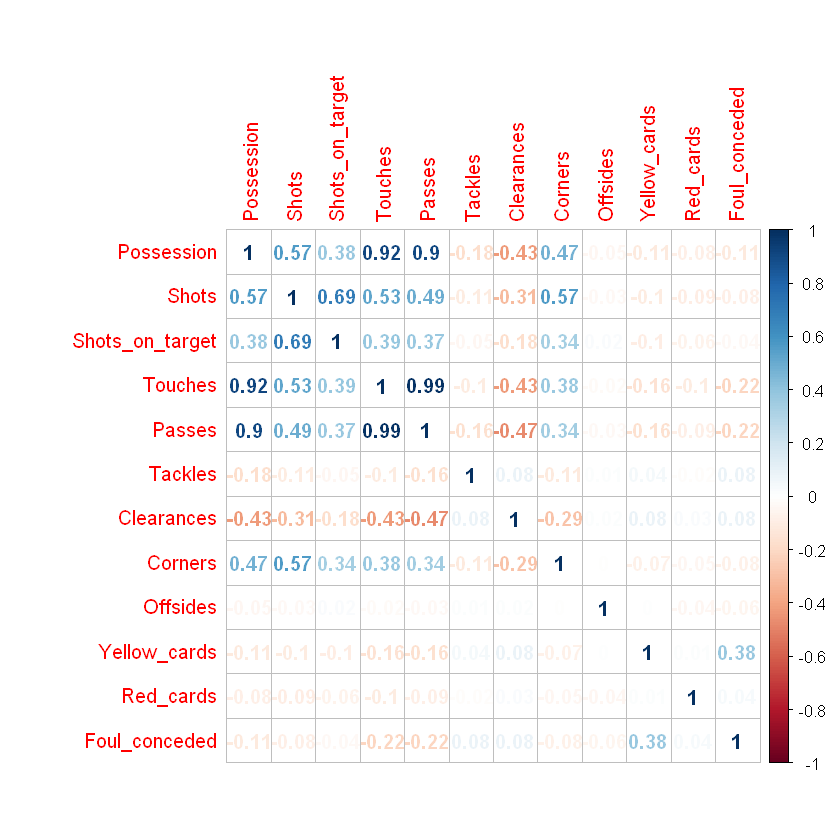

```r
corrplot(data_cor, method = 'number')
```

## 전체팀의 각 스텟별 상관 비교

- 유의하지 않은 -0.3에서 0.3 사이의 수치는 NA 처리

### 점유율

```r
Possession_df  <- cbind(cor(data,data[1]))
for (i in 1:12){
        if (Possession_df[i]<=0.3 & Possession_df[i]>= -0.3){
            Possession_df[i] <- NA
        }
    }
```

```r
# 점유율
Possession_df
```

|  | Possession |
| --- | --- |
| Possession | 1.0000000 |
| Shots | 0.5676834 |
| Shots_on_target | 0.3776398 |
| Touches | 0.9169454 |
| Passes | 0.9034598 |
| Tackles | NA |
| Clearances | -0.4285371 |
| Corners | 0.4700220 |
| Offsides | NA |
| Yellow_cards | NA |
| Red_cards | NA |
| Foul_conceded | NA |

점유율 같은 경우 , 터치수와 패스수 하고 매우 강한 양의 상관관계를 보였다. 코너킥하고는 중간정도의 양의 상관관계를 보였다.

공을 걷어내는 횟수는 점유율과 중간정도 음의 상관관계를 가졌다. 점유율이 높은 축구를 구사하다 보면 공격을 주로 하기 때문에 자연스레 공을 걷어낼 기회가 줄어들 수밖에 없다.

점유율과 오프사이드의 관계는 양의 상관관계를 가질 것이라고 생각했던거 하고는 달리 상관관계를 찾을 수 없었다.

### 슛

```r
Shots_df  <- cbind(cor(data,data[2]))
for (i in 1:12){
        if (Shots_df[i]<=0.3 & Shots_df[i]>= -0.3){
            Shots_df[i] <- NA
        }
    }
```

```r
# 슛
Shots_df
```

|  | Shots |
| --- | --- |
| Possession | 0.5676834 |
| Shots | 1.0000000 |
| Shots_on_target | 0.6935721 |
| Touches | 0.5275513 |
| Passes | 0.4930621 |
| Tackles | NA |
| Clearances | -0.3116362 |
| Corners | 0.5679867 |
| Offsides | NA |
| Yellow_cards | NA |
| Red_cards | NA |
| Foul_conceded | NA |

Shots와 Shots_on_target은 그래도 0.8 이상의 상관관계 가 있을 것으로 예상됬으나 거기에 미치지 못했다.

Shots 와 Touches는 다소 높은 상관관계가 있다. Passes 와는 중간정도 상관관계가 있다. Shots 과 Corner 가 다소 높은 상관관계가 있다. 슛을 할때 상대방 몸을 맞고 나가는 경우도 많을 것이라는 추측을 해 볼 수 있다.

### 유효슛

```r
Shots_on_target_df  <- cbind(cor(data,data[3]))
for (i in 1:12){
        if (Shots_on_target_df[i]<=0.3 & Shots_on_target_df[i]>= -0.3){
            Shots_on_target_df[i] <- NA
        }
    }
```

```r
Shots_on_target_df
```

|  | Shots_on_target |
| --- | --- |
| Possession | 0.3776398 |
| Shots | 0.6935721 |
| Shots_on_target | 1.0000000 |
| Touches | 0.3865260 |
| Passes | 0.3720592 |
| Tackles | NA |
| Clearances | NA |
| Corners | 0.3367878 |
| Offsides | NA |
| Yellow_cards | NA |
| Red_cards | NA |
| Foul_conceded | NA |

대체로 Shots_on_target 과 다른 변수들간의 관계는 Shots와 다른 변수들간의 관계보다 약하다.

### 터치

```r
Touches_df  <- cbind(cor(data,data[4]))
for (i in 1:12){
        if (Touches_df[i]<=0.3 & Touches_df[i]>= -0.3){
            Touches_df[i] <- NA
        }
    }
```

```r
Touches_df
```

|  | Touches |
| --- | --- |
| Possession | 0.9169454 |
| Shots | 0.5275513 |
| Shots_on_target | 0.3865260 |
| Touches | 1.0000000 |
| Passes | 0.9866489 |
| Tackles | NA |
| Clearances | -0.4259102 |
| Corners | 0.3766902 |
| Offsides | NA |
| Yellow_cards | NA |
| Red_cards | NA |
| Foul_conceded | NA |

Touches 는 Passes 하고 완전 선형관계일 정도이다. 그리고 점유율 하고도 뚜렷한 상관관계를 보이고 있다.

### 패스

```r
Passes_df  <- cbind(cor(data,data[5]))
for (i in 1:12){
        if (Passes_df[i]<=0.3 & Passes_df[i]>= -0.3){
            Passes_df[i] <- NA
        }
    }
```

```r
Passes_df
```

|  | Passes |
| --- | --- |
| Possession | 0.9034598 |
| Shots | 0.4930621 |
| Shots_on_target | 0.3720592 |
| Touches | 0.9866489 |
| Passes | 1.0000000 |
| Tackles | NA |
| Clearances | -0.4745386 |
| Corners | 0.3414550 |
| Offsides | NA |
| Yellow_cards | NA |
| Red_cards | NA |
| Foul_conceded | NA |

### 태클

```r
Tackles_df  <- cbind(cor(data,data[6]))
for (i in 1:12){
        if (Tackles_df[i]<=0.3 & Tackles_df[i]>= -0.3){
            Tackles_df[i] <- NA
        }
    }
```

```r
Tackles_df
```

|  | Tackles |
| --- | --- |
| Possession | NA |
| Shots | NA |
| Shots_on_target | NA |
| Touches | NA |
| Passes | NA |
| Tackles | 1 |
| Clearances | NA |
| Corners | NA |
| Offsides | NA |
| Yellow_cards | NA |
| Red_cards | NA |
| Foul_conceded | NA |

태클은 어떠한 변수와도 관련이 없다.

### 클리어링

```r
Clearances_df  <- cbind(cor(data,data[7]))
for (i in 1:12){
        if (Clearances_df[i]<=0.3 & Clearances_df[i]>= -0.3){
            Clearances_df[i] <- NA
        }
    }
```

```r
Clearances_df
```

|  | Clearances |
| --- | --- |
| Possession | -0.4285371 |
| Shots | -0.3116362 |
| Shots_on_target | NA |
| Touches | -0.4259102 |
| Passes | -0.4745386 |
| Tackles | NA |
| Clearances | 1.0000000 |
| Corners | NA |
| Offsides | NA |
| Yellow_cards | NA |
| Red_cards | NA |
| Foul_conceded | NA |

클리어링은 점유율,터치,패스,슛 하고 관련이 있다.

### 코너킥

```r
Corners_df  <- cbind(cor(data,data[8]))
for (i in 1:12){
        if (Corners_df[i]<=0.3 & Corners_df[i]>= -0.3){
            Corners_df[i] <- NA
        }
    }
```

```r
Corners_df
```

|  | Corners |
| --- | --- |
| Possession | 0.4700220 |
| Shots | 0.5679867 |
| Shots_on_target | 0.3367878 |
| Touches | 0.3766902 |
| Passes | 0.3414550 |
| Tackles | NA |
| Clearances | NA |
| Corners | 1.0000000 |
| Offsides | NA |
| Yellow_cards | NA |
| Red_cards | NA |
| Foul_conceded | NA |

코너킥은 점유율,터치,패스,슛,유효슛과 관련이 있다.

### 오프사이드

```r
Offisides_df  <- cbind(cor(data,data[9]))
for (i in 1:12){
        if (Offisides_df[i]<=0.3 & Offisides_df[i]>= -0.3){
            Offisides_df[i] <- NA
        }
    }
```

```r
Offisides_df
```

|  | Offsides |
| --- | --- |
| Possession | NA |
| Shots | NA |
| Shots_on_target | NA |
| Touches | NA |
| Passes | NA |
| Tackles | NA |
| Clearances | NA |
| Corners | NA |
| Offsides | 1 |
| Yellow_cards | NA |
| Red_cards | NA |
| Foul_conceded | NA |

오프사이드는 어떠한 변수와도 관련이 없다.

### 옐로카드

```r
Yellow_cards_df  <- cbind(cor(data,data[10]))
for (i in 1:12){
        if (Yellow_cards_df[i]<=0.3 & Yellow_cards_df[i]>= -0.3){
            Yellow_cards_df[i] <- NA
        }
    }
```

```r
Yellow_cards_df
```

|  | Yellow_cards |
| --- | --- |
| Possession | NA |
| Shots | NA |
| Shots_on_target | NA |
| Touches | NA |
| Passes | NA |
| Tackles | NA |
| Clearances | NA |
| Corners | NA |
| Offsides | NA |
| Yellow_cards | 1.0000000 |
| Red_cards | NA |
| Foul_conceded | 0.3797568 |

옐로카드는 파울과 관련이 있다.

### 레드카드

```r
Red_cards_df  <- cbind(cor(data,data[11]))
for (i in 1:12){
        if (Red_cards_df[i]<=0.3 & Red_cards_df[i]>= -0.3){
            Red_cards_df[i] <- NA
        }
    }
```

```r
Red_cards_df
```

|  | Red_cards |
| --- | --- |
| Possession | NA |
| Shots | NA |
| Shots_on_target | NA |
| Touches | NA |
| Passes | NA |
| Tackles | NA |
| Clearances | NA |
| Corners | NA |
| Offsides | NA |
| Yellow_cards | NA |
| Red_cards | 1 |
| Foul_conceded | NA |

레드카드는 어떠한 변수와도 관련이 없다.

### 파울

```r
Foul_conceded_df  <- cbind(cor(data,data[12]))
for (i in 1:12){
        if (Foul_conceded_df[i]<=0.3 & Foul_conceded_df[i]>= -0.3){
            Foul_conceded_df[i] <- NA
        }
    }
```

```r
Foul_conceded_df
```

|  | Foul_conceded |
| --- | --- |
| Possession | NA |
| Shots | NA |
| Shots_on_target | NA |
| Touches | NA |
| Passes | NA |
| Tackles | NA |
| Clearances | NA |
| Corners | NA |
| Offsides | NA |
| Yellow_cards | 0.3797568 |
| Red_cards | NA |
| Foul_conceded | 1.0000000 |

파울은 옐로카드와 관련이 있다.

## 결과

절대값 0.7 이상의 높은 상관을 가지는 관계는 다음과 같다.

- 점유율과 패스
- 점유율과 터치
- 패스와 터치

상관계수 값이 0.3 이상인 관계들에 대해서 관계가 높은 순서부터 정리하면 다음과 같다.

- 터치와 패스 0.987
- 점유율과 터치 0.917
- 점유율과 패스 0.903
- 슛과 유효슛 0.694
- 점유율과 슛 0.568
- 슛과 코너킥 0.567
- 슛과 터치 0.528
- 슛과 패스 0.493
- 점유율과 코너킥 0.470
- 유효슛과 터치 0.387
- 옐로카드와 파울 0.380
- 점유율과 유효슛 0.377
- 터치와 코너킥 0.377
- 유효슛과 패스 0.372
- 패스와 코너킥 0.341
- 유효슛과 코너킥 0.336

상관계수 값이 -0.3 이하인 관계들에 대해서 관계가 높은 순서부터 정리하면 다음과 같다.

- 패스와 클리어링 -0.475
- 점유율과 클리어링 -0.429
- 터치와 클리어링 -0.426
- 슛과 클리어링 -0.311

# 변수들간의 선형회귀 분석

- 각 변수들간의 구체적인 관계를 알아보기 위해 선형관계 모델링 도입
- 상관계수 절대값이 0.3 이상인 관계에 대해서만 선형관계로 모델링
- 모델링 된 관계를 보여주는데 요약본과 그래프를 이용
- 양의 상관관계에서 상관계수가 제일 높았던 터치,패스의 관계와 음의 상관관계에서 상관계수가 가장 높았던 패스,클리어링 관계에 대해서 선형관계에 대한 해석 진행
- 나머지 상관관계에 대한 선형관계 모델링 코딩은 범주를 양의 상관관계와 음의 상관관계로 나눈후, 상관계수의 절대값이 높은 순서대로 시각화

### 패스와 터치의 관계

```
Call:
lm(formula = Passes ~ Touches, data = data)

Residuals:
    Min      1Q  Median      3Q     Max
-81.761 -14.726   0.181  14.504  83.664

Coefficients:
              Estimate Std. Error t value Pr(>|t|)
(Intercept) -1.896e+02  1.747e+00  -108.5   <2e-16 ***
Touches      9.861e-01  2.641e-03   373.4   <2e-16 ***
---
Signif. codes:  0 '***' 0.001 '**' 0.01 '*' 0.05 '.' 0.1 ' ' 1

Residual standard error: 21.49 on 3798 degrees of freedom
Multiple R-squared:  0.9735,	Adjusted R-squared:  0.9735
F-statistic: 1.394e+05 on 1 and 3798 DF,  p-value: < 2.2e-16
```

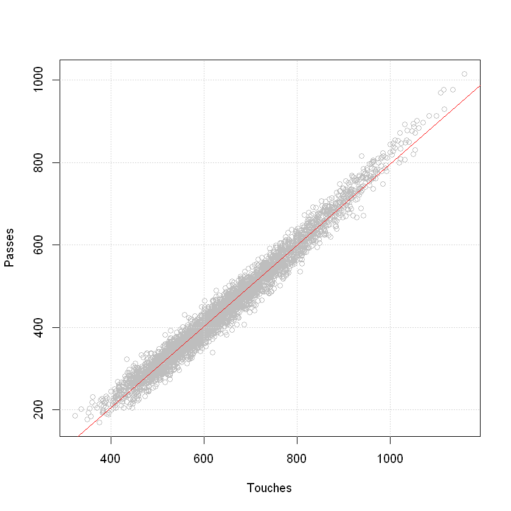

```r
LM  <- lm(data = data , Passes~Touches)
plot(Passes~Touches, data = data, col = 'grey')
grid()
abline(LM, col='red')
summary(LM)
```

터치 1개 증가할 때마다 패스 0.9861개씩 증가

### 패스와 클리어링의 관계

```
Call:
lm(formula = Clearances ~ Passes, data = data)

Residuals:
    Min      1Q  Median      3Q     Max
-23.831  -6.508  -0.947   5.584  47.032

Coefficients:
             Estimate Std. Error t value Pr(>|t|)
(Intercept) 40.965329   0.528564   77.50   <2e-16 ***
Passes      -0.037488   0.001128  -33.22   <2e-16 ***
---
Signif. codes:  0 '***' 0.001 '**' 0.01 '*' 0.05 '.' 0.1 ' ' 1

Residual standard error: 9.175 on 3798 degrees of freedom
Multiple R-squared:  0.2252,	Adjusted R-squared:  0.225
F-statistic:  1104 on 1 and 3798 DF,  p-value: < 2.2e-16
```

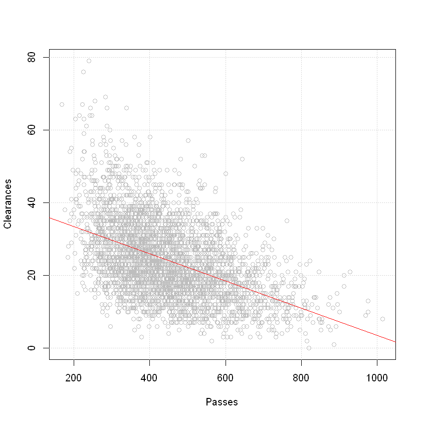

```r
LM  <- lm(data = data , Clearances~Passes)
plot(Clearances~Passes, data = data, col = 'grey')
grid()
abline(LM, col='red')
summary(LM)
```

패스가 1개씩 늘어날 때마다 클리어링은 0.0376개씩 줄어듬

## 양의 상관관계

### 점유율과 터치의 선형관계

```
Call:
lm(formula = Touches ~ Possession, data = data)

Residuals:
    Min      1Q  Median      3Q     Max
-183.98  -34.45    0.07   32.84  282.38

Coefficients:
             Estimate Std. Error t value Pr(>|t|)
(Intercept) 168.19511    3.49488   48.13   <2e-16 ***
Possession    9.59865    0.06778  141.62   <2e-16 ***
---
Signif. codes:  0 '***' 0.001 '**' 0.01 '*' 0.05 '.' 0.1 ' ' 1

Residual standard error: 52.68 on 3798 degrees of freedom
Multiple R-squared:  0.8408,	Adjusted R-squared:  0.8407
F-statistic: 2.006e+04 on 1 and 3798 DF,  p-value: < 2.2e-16
```

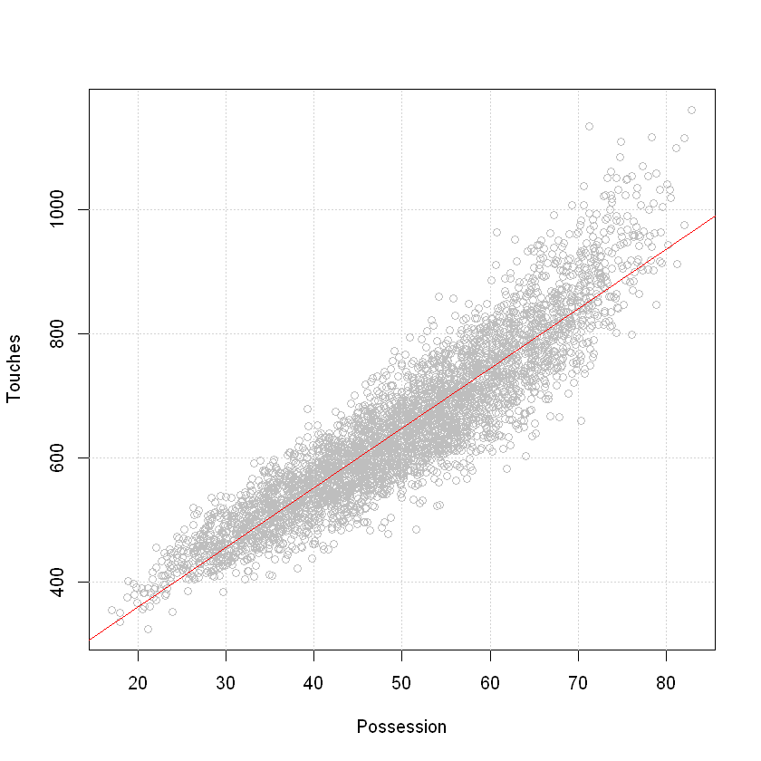

```r
LM  <- lm(data = data , Touches~Possession)
plot(Touches~Possession, data = data, col = 'grey')
grid()
abline(LM, col='red')
summary(LM)
```

### 점유율과 패스의 선형관계

```
Call:
lm(formula = Passes ~ Possession, data = data)

Residuals:
    Min      1Q  Median      3Q     Max
-177.81  -36.45   -2.19   33.63  326.13

Coefficients:
             Estimate Std. Error t value Pr(>|t|)
(Intercept) -23.11937    3.75251  -6.161 7.98e-10 ***
Possession    9.45205    0.07277 129.885  < 2e-16 ***
---
Signif. codes:  0 '***' 0.001 '**' 0.01 '*' 0.05 '.' 0.1 ' ' 1

Residual standard error: 56.56 on 3798 degrees of freedom
Multiple R-squared:  0.8162,	Adjusted R-squared:  0.8162
F-statistic: 1.687e+04 on 1 and 3798 DF,  p-value: < 2.2e-16
```

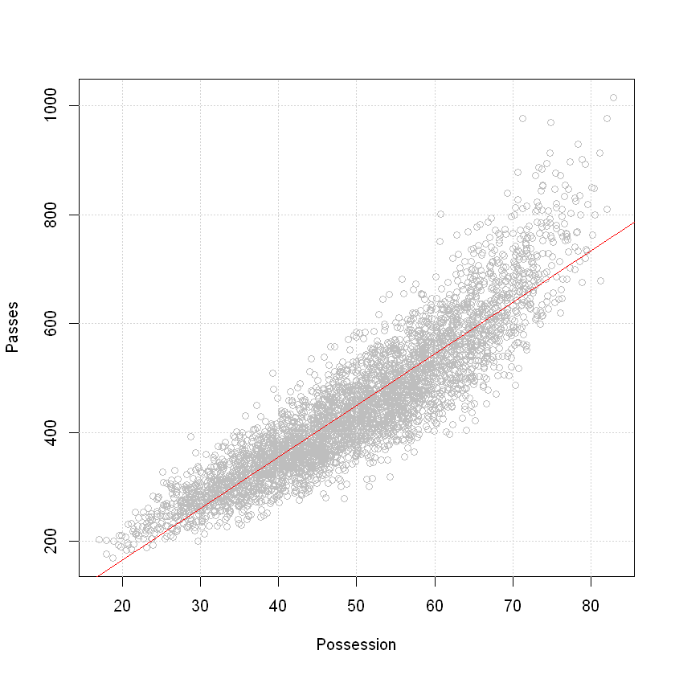

```r
LM  <- lm(data = data , Passes~Possession)
plot(Passes~Possession, data = data, col = 'grey')
grid()
abline(LM, col='red')
summary(LM)
```

### 슛과 유효슛의 선형관계

```
Call:
lm(formula = Shots_on_target ~ Shots, data = data)

Residuals:
    Min      1Q  Median      3Q     Max
-7.6418 -1.1606 -0.0951  1.1618  8.0031

Coefficients:
            Estimate Std. Error t value Pr(>|t|)
(Intercept) 0.226046   0.074559   3.032  0.00245 **
Shots       0.322423   0.005434  59.334  < 2e-16 ***
---
Signif. codes:  0 '***' 0.001 '**' 0.01 '*' 0.05 '.' 0.1 ' ' 1

Residual standard error: 1.827 on 3798 degrees of freedom
Multiple R-squared:  0.481,	Adjusted R-squared:  0.4809
F-statistic:  3521 on 1 and 3798 DF,  p-value: < 2.2e-16
```

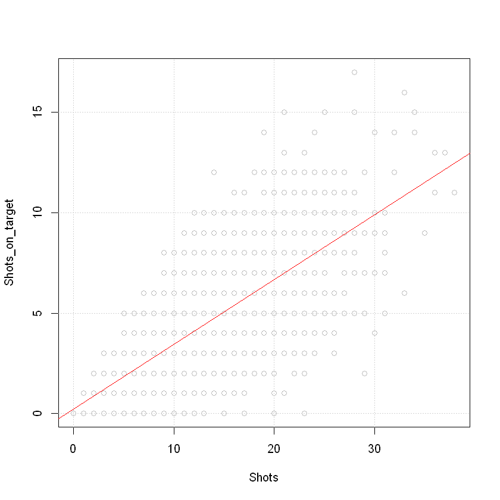

```r
LM  <- lm(data = data , Shots_on_target~Shots)
plot(Shots_on_target~Shots, data = data, col = 'grey')
grid()
abline(LM, col='red')
summary(LM)
```

### 점유율과 슛의 선형관계

```
Call:
lm(formula = Shots ~ Possession, data = data)

Residuals:
     Min       1Q   Median       3Q      Max
-13.2248  -3.1239  -0.3686   2.7445  20.5471

Coefficients:
            Estimate Std. Error t value Pr(>|t|)
(Intercept)  0.30919    0.29802   1.037      0.3
Possession   0.24561    0.00578  42.497   <2e-16 ***
---
Signif. codes:  0 '***' 0.001 '**' 0.01 '*' 0.05 '.' 0.1 ' ' 1

Residual standard error: 4.492 on 3798 degrees of freedom
Multiple R-squared:  0.3223,	Adjusted R-squared:  0.3221
F-statistic:  1806 on 1 and 3798 DF,  p-value: < 2.2e-16
```

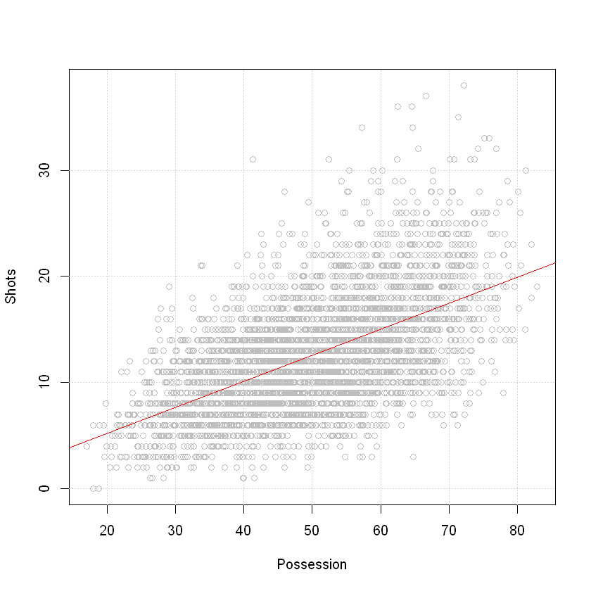

```r
LM  <- lm(data = data , Shots~Possession)
plot(Shots~Possession, data = data, col = 'grey')
grid()
abline(LM, col='red')
summary(LM)
```

### 슛과 코너킥의 선형관계

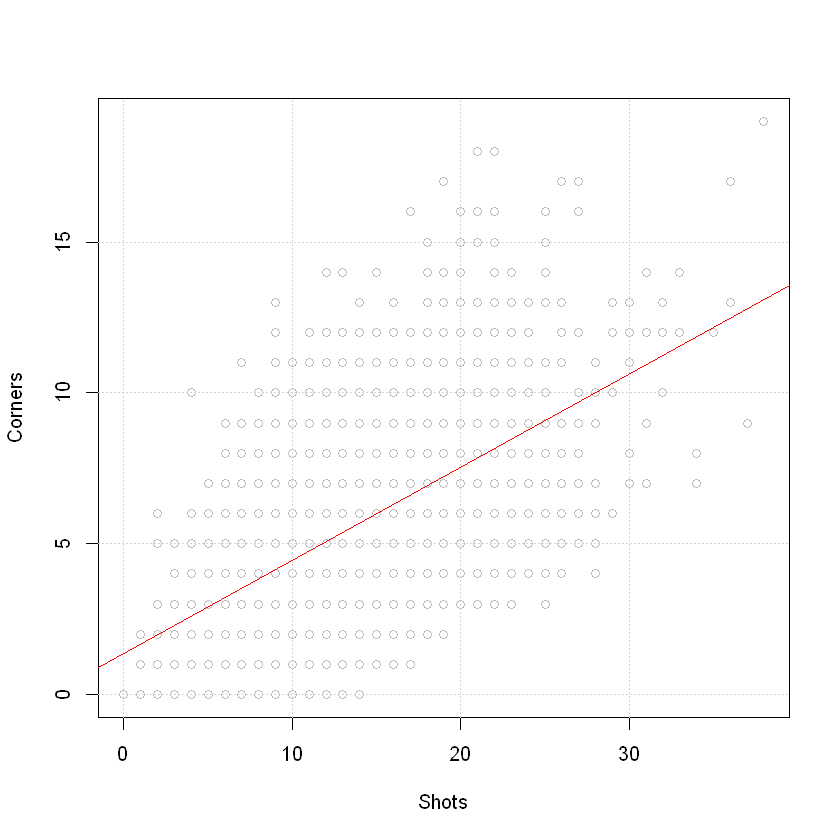

```r
LM  <- lm(data = data , Corners~Shots)
plot(Corners~Shots, data = data, col = 'grey')
grid()
abline(LM, col='red')
```

### 슛과 터치의 선형관계

```
Call:
lm(formula = Touches ~ Shots, data = data)

Residuals:
    Min      1Q  Median      3Q     Max
-321.12  -79.84   -9.63   71.47  480.64

Coefficients:
            Estimate Std. Error t value Pr(>|t|)
(Intercept) 487.4309     4.5761  106.52   <2e-16 ***
Shots        12.7641     0.3335   38.27   <2e-16 ***
---
Signif. codes:  0 '***' 0.001 '**' 0.01 '*' 0.05 '.' 0.1 ' ' 1

Residual standard error: 112.2 on 3798 degrees of freedom
Multiple R-squared:  0.2783,	Adjusted R-squared:  0.2781
F-statistic:  1465 on 1 and 3798 DF,  p-value: < 2.2e-16
```

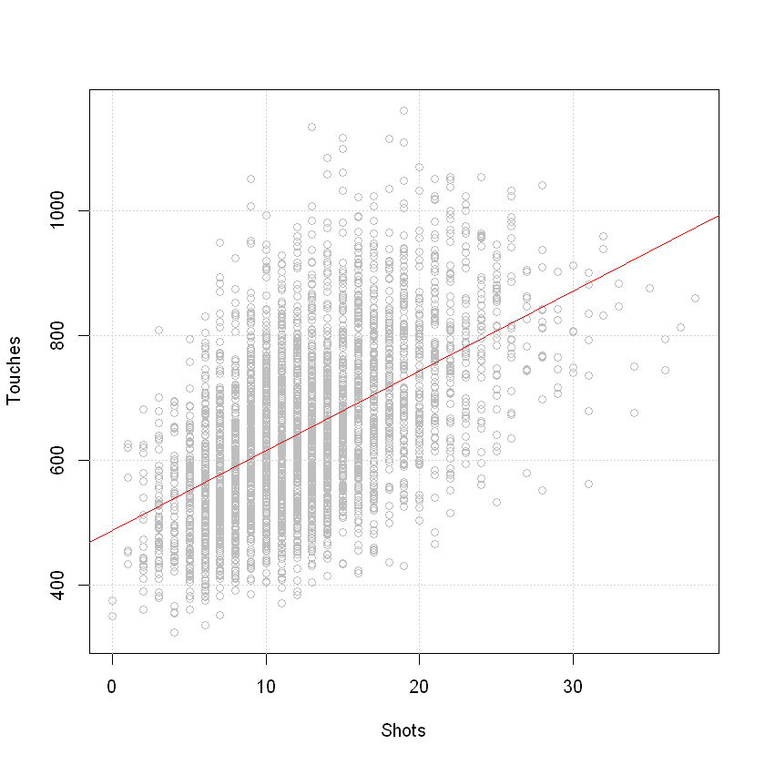

```r
LM  <- lm(data = data , Touches~Shots)
plot(Touches~Shots, data = data, col = 'grey')
grid()
abline(LM, col='red')
summary(LM)
```

### 슛과 패스의 선형관계

```
Call:
lm(formula = Passes ~ Shots, data = data)

Residuals:
    Min      1Q  Median      3Q     Max
-328.98  -82.14  -11.84   72.64  521.63

Coefficients:
            Estimate Std. Error t value Pr(>|t|)
(Intercept) 299.3784     4.6837   63.92   <2e-16 ***
Shots        11.9228     0.3414   34.93   <2e-16 ***
---
Signif. codes:  0 '***' 0.001 '**' 0.01 '*' 0.05 '.' 0.1 ' ' 1

Residual standard error: 114.8 on 3798 degrees of freedom
Multiple R-squared:  0.2431,	Adjusted R-squared:  0.2429
F-statistic:  1220 on 1 and 3798 DF,  p-value: < 2.2e-16
```

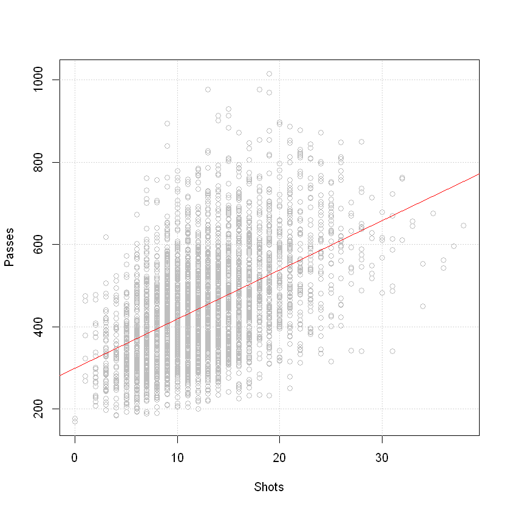

```r
LM  <- lm(data = data , Passes~Shots)
plot(Passes~Shots, data = data, col = 'grey')
grid()
abline(LM, col='red')
summary(LM)
```

### 점유율과 코너킥의 선형관계

```
Call:
lm(formula = Corners ~ Possession, data = data)

Residuals:
    Min      1Q  Median      3Q     Max
-7.4829 -1.8477 -0.2271  1.6005 12.5623

Coefficients:
             Estimate Std. Error t value Pr(>|t|)
(Intercept) -0.277804   0.173706  -1.599     0.11
Possession   0.110551   0.003369  32.817   <2e-16 ***
---
Signif. codes:  0 '***' 0.001 '**' 0.01 '*' 0.05 '.' 0.1 ' ' 1

Residual standard error: 2.618 on 3798 degrees of freedom
Multiple R-squared:  0.2209,	Adjusted R-squared:  0.2207
F-statistic:  1077 on 1 and 3798 DF,  p-value: < 2.2e-16
```

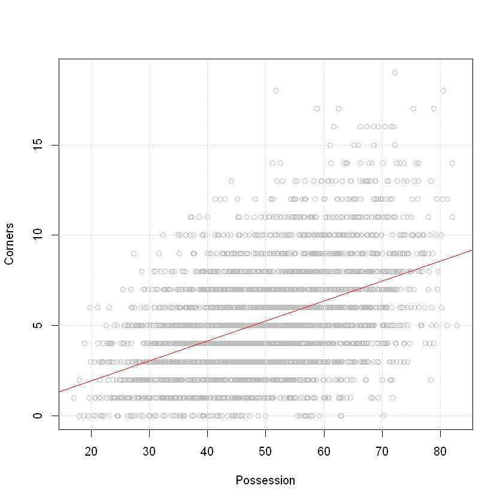

```r
LM  <- lm(data = data , Corners~Possession)
plot(Corners~Possession, data = data, col = 'grey')
grid()
abline(LM, col='red')
summary(LM)
```

### 유효슛과 터치의 선형관계

```
Call:
lm(formula = Touches ~ Shots_on_target, data = data)

Residuals:
    Min      1Q  Median      3Q     Max
-332.86  -88.18  -10.42   77.23  511.73

Coefficients:
                Estimate Std. Error t value Pr(>|t|)
(Intercept)     561.9194     3.8784  144.88   <2e-16 ***
Shots_on_target  20.1173     0.7789   25.83   <2e-16 ***
---
Signif. codes:  0 '***' 0.001 '**' 0.01 '*' 0.05 '.' 0.1 ' ' 1

Residual standard error: 121.8 on 3798 degrees of freedom
Multiple R-squared:  0.1494,	Adjusted R-squared:  0.1492
F-statistic: 667.1 on 1 and 3798 DF,  p-value: < 2.2e-16
```

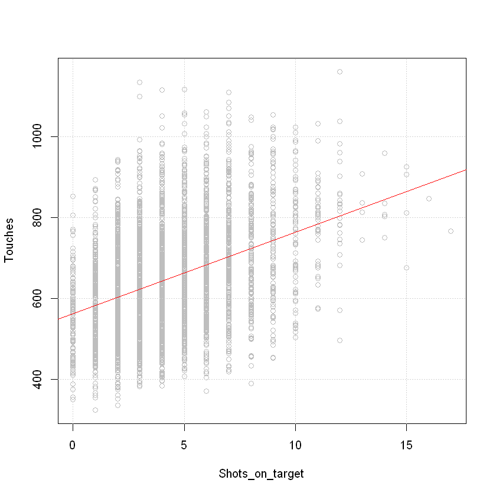

```r
LM  <- lm(data = data , Touches~Shots_on_target)
plot(Touches~Shots_on_target, data = data, col = 'grey')
grid()
abline(LM, col='red')
summary(LM)
```

### 파울과 옐로카드의 선형관계

[output not shown]

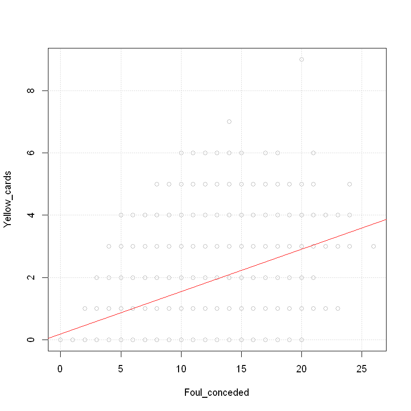

```r
LM2  <- lm(data = data , Yellow_cards~Foul_conceded)
plot(Yellow_cards~Foul_conceded, data = data, col = 'grey')
grid()
abline(LM2, col='red')
summary(LM)
```

### 유효슛과 점유율의 선형관계

```
Call:
lm(formula = Shots_on_target ~ Possession, data = data)

Residuals:
    Min      1Q  Median      3Q     Max
-5.8271 -1.6472 -0.2182  1.3894 11.9856

Coefficients:
            Estimate Std. Error t value Pr(>|t|)
(Intercept) 0.487541   0.155827   3.129  0.00177 **
Possession  0.075954   0.003022  25.134  < 2e-16 ***
---
Signif. codes:  0 '***' 0.001 '**' 0.01 '*' 0.05 '.' 0.1 ' ' 1

Residual standard error: 2.349 on 3798 degrees of freedom
Multiple R-squared:  0.1426,	Adjusted R-squared:  0.1424
F-statistic: 631.7 on 1 and 3798 DF,  p-value: < 2.2e-16
```

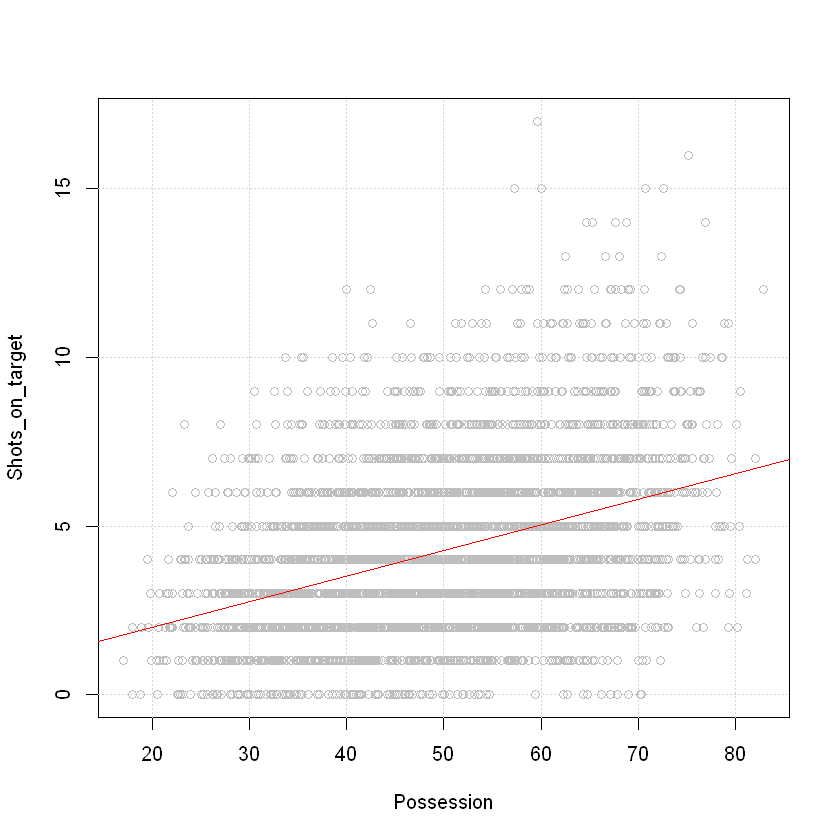

```r
LM  <- lm(data = data , Shots_on_target~Possession)
plot(Shots_on_target~Possession, data = data, col = 'grey')
grid()
abline(LM, col='red')
summary(LM)
```

### 터치와 코너킥의 선형관계

```
Call:
lm(formula = Corners ~ Touches, data = data)

Residuals:
    Min      1Q  Median      3Q     Max
-7.8132 -1.9411 -0.2946  1.6582 13.3607

Coefficients:
              Estimate Std. Error t value Pr(>|t|)
(Intercept) -0.2358358  0.2233847  -1.056    0.291
Touches      0.0084637  0.0003377  25.061   <2e-16 ***
---
Signif. codes:  0 '***' 0.001 '**' 0.01 '*' 0.05 '.' 0.1 ' ' 1

Residual standard error: 2.748 on 3798 degrees of freedom
Multiple R-squared:  0.1419,	Adjusted R-squared:  0.1417
F-statistic:   628 on 1 and 3798 DF,  p-value: < 2.2e-16
```

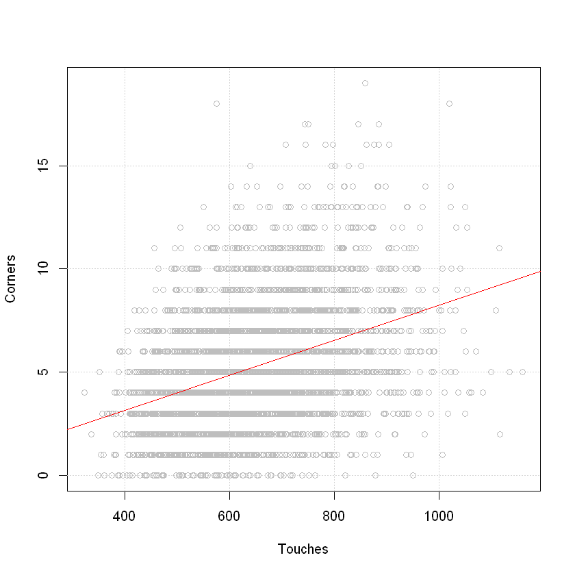

```r
LM  <- lm(data = data , Corners~Touches)
plot(Corners~Touches, data = data, col = 'grey')
grid()
abline(LM, col='red')
summary(LM)
```

### 유효슛과 패스의 선형관계

```
Call:
lm(formula = Passes ~ Shots_on_target, data = data)

Residuals:
    Min      1Q  Median      3Q     Max
-301.38  -87.98  -11.96   75.46  551.39

Coefficients:
                Estimate Std. Error t value Pr(>|t|)
(Intercept)     366.5492     3.9011   93.96   <2e-16 ***
Shots_on_target  19.3532     0.7834   24.70   <2e-16 ***
---
Signif. codes:  0 '***' 0.001 '**' 0.01 '*' 0.05 '.' 0.1 ' ' 1

Residual standard error: 122.5 on 3798 degrees of freedom
Multiple R-squared:  0.1384,	Adjusted R-squared:  0.1382
F-statistic: 610.2 on 1 and 3798 DF,  p-value: < 2.2e-16
```

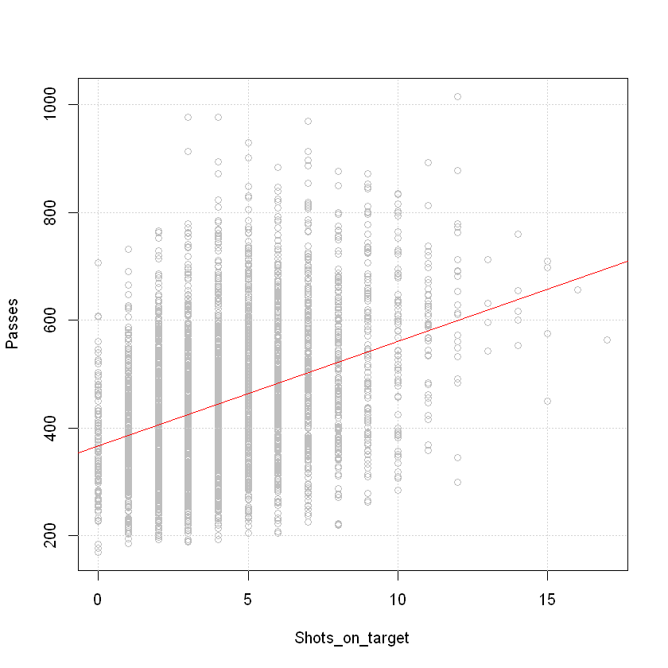

```r
LM  <- lm(data = data , Passes~Shots_on_target)
plot(Passes~Shots_on_target, data = data, col = 'grey')
grid()
abline(LM, col='red')
summary(LM)
```

### 패스와 코너킥의 선형관계

```
Call:
lm(formula = Corners ~ Passes, data = data)

Residuals:
    Min      1Q  Median      3Q     Max
-7.6488 -1.9835 -0.3057  1.6854 13.5677

Coefficients:
             Estimate Std. Error t value Pr(>|t|)
(Intercept) 1.7993046  0.1606137   11.20   <2e-16 ***
Passes      0.0076764  0.0003429   22.39   <2e-16 ***
---
Signif. codes:  0 '***' 0.001 '**' 0.01 '*' 0.05 '.' 0.1 ' ' 1

Residual standard error: 2.788 on 3798 degrees of freedom
Multiple R-squared:  0.1166,	Adjusted R-squared:  0.1164
F-statistic: 501.3 on 1 and 3798 DF,  p-value: < 2.2e-16
```

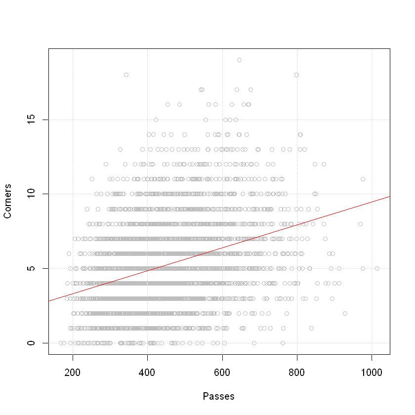

```r
LM  <- lm(data = data , Corners~Passes)
plot(Corners~Passes, data = data, col = 'grey')
grid()
abline(LM, col='red')
summary(LM)
```

### 유효슛과 코너킥의 선형관계

```
Call:
lm(formula = Corners ~ Shots_on_target, data = data)

Residuals:
    Min      1Q  Median      3Q     Max
-6.8943 -2.1374 -0.3497  1.6811 12.4688

Coefficients:
                Estimate Std. Error t value Pr(>|t|)
(Intercept)      3.56201    0.08897   40.04   <2e-16 ***
Shots_on_target  0.39384    0.01787   22.04   <2e-16 ***
---
Signif. codes:  0 '***' 0.001 '**' 0.01 '*' 0.05 '.' 0.1 ' ' 1

Residual standard error: 2.793 on 3798 degrees of freedom
Multiple R-squared:  0.1134,	Adjusted R-squared:  0.1132
F-statistic: 485.9 on 1 and 3798 DF,  p-value: < 2.2e-16
```

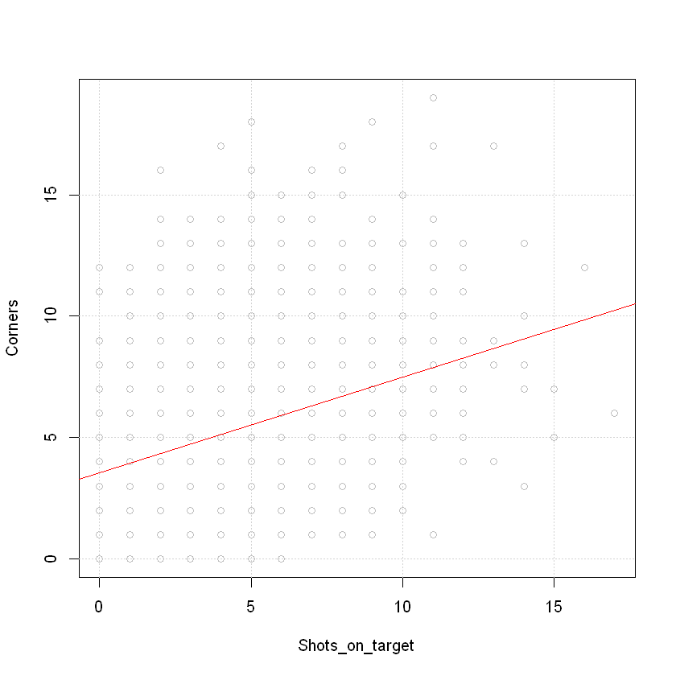

```r
LM  <- lm(data = data , Corners~Shots_on_target)
plot(Corners~Shots_on_target, data = data, col = 'grey')
grid()
abline(LM, col='red')
summary(LM)
```

## 음의 상관관계

### 점유율과 클리어링의 선형관계

```
Call:
lm(formula = Clearances ~ Possession, data = data)

Residuals:
    Min      1Q  Median      3Q     Max
-24.172  -6.719  -1.060   5.685  49.926

Coefficients:
            Estimate Std. Error t value Pr(>|t|)
(Intercept) 41.82421    0.62483   66.94   <2e-16 ***
Possession  -0.35418    0.01212  -29.23   <2e-16 ***
---
Signif. codes:  0 '***' 0.001 '**' 0.01 '*' 0.05 '.' 0.1 ' ' 1

Residual standard error: 9.418 on 3798 degrees of freedom
Multiple R-squared:  0.1836,	Adjusted R-squared:  0.1834
F-statistic: 854.4 on 1 and 3798 DF,  p-value: < 2.2e-16
```

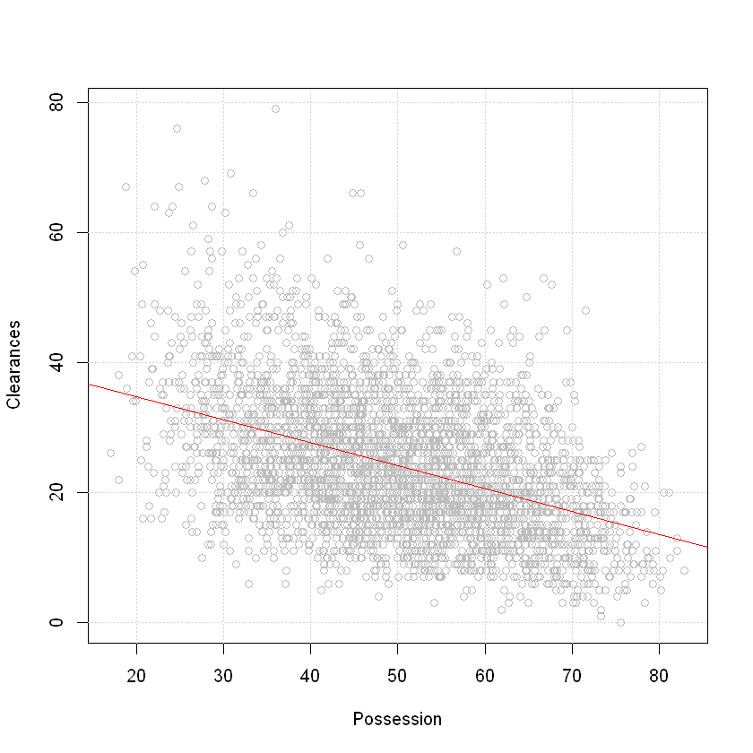

```r
LM  <- lm(data = data , Clearances~Possession)
plot(Clearances~Possession, data = data, col = 'grey')
grid()
abline(LM, col='red')
summary(LM)
```

### 터치와 클리어링의 선형관계

```
Call:
lm(formula = Clearances ~ Touches, data = data)

Residuals:
    Min      1Q  Median      3Q     Max
-25.114  -6.712  -1.050   5.773  48.357

Coefficients:
             Estimate Std. Error t value Pr(>|t|)
(Intercept) 45.909788   0.766684   59.88   <2e-16 ***
Touches     -0.033627   0.001159  -29.01   <2e-16 ***
---
Signif. codes:  0 '***' 0.001 '**' 0.01 '*' 0.05 '.' 0.1 ' ' 1

Residual standard error: 9.431 on 3798 degrees of freedom
Multiple R-squared:  0.1814,	Adjusted R-squared:  0.1812
F-statistic: 841.6 on 1 and 3798 DF,  p-value: < 2.2e-16
```

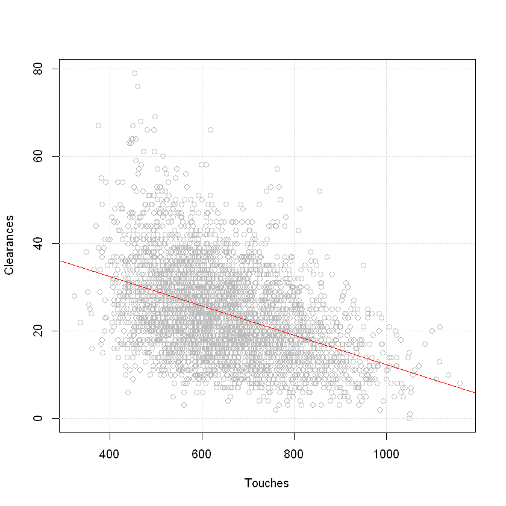

```r
LM  <- lm(data = data , Clearances~Touches)
plot(Clearances~Touches, data = data, col = 'grey')
grid()
abline(LM, col='red')
summary(LM)
```

### 슛과 클리어링의 선형관계

```
Call:
lm(formula = Clearances ~ Shots, data = data)

Residuals:
    Min      1Q  Median      3Q     Max
-23.443  -7.252  -1.108   5.874  52.153

Coefficients:
            Estimate Std. Error t value Pr(>|t|)
(Intercept) 31.60986    0.40412   78.22   <2e-16 ***
Shots       -0.59532    0.02945  -20.21   <2e-16 ***
---
Signif. codes:  0 '***' 0.001 '**' 0.01 '*' 0.05 '.' 0.1 ' ' 1

Residual standard error: 9.904 on 3798 degrees of freedom
Multiple R-squared:  0.09712,	Adjusted R-squared:  0.09688
F-statistic: 408.5 on 1 and 3798 DF,  p-value: < 2.2e-16
```

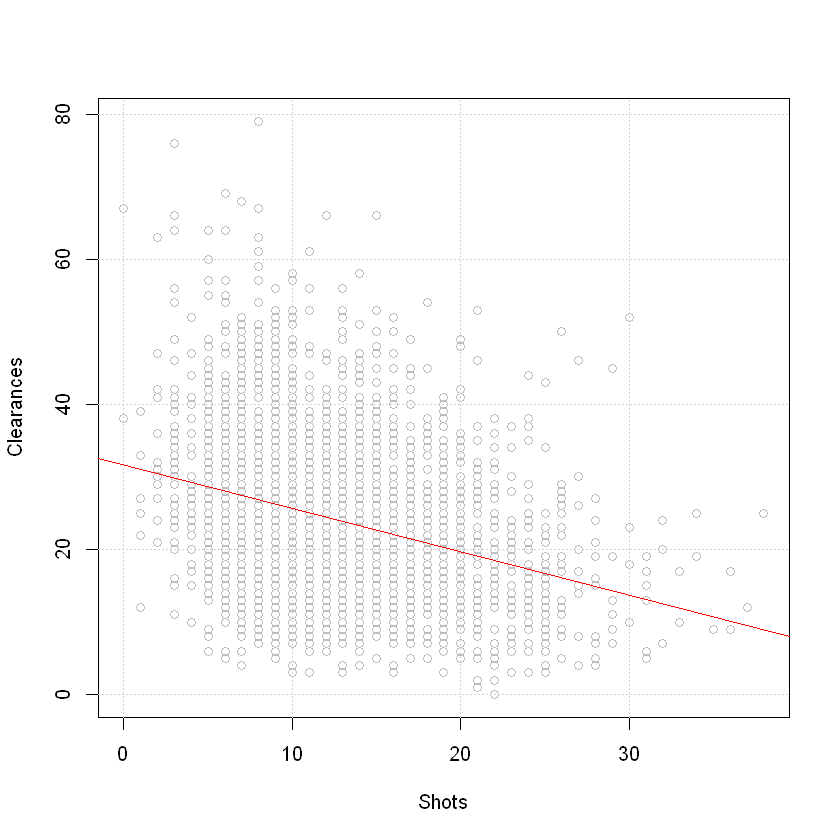

```r
LM  <- lm(data = data , Clearances~Shots)
plot(Clearances~Shots, data = data, col = 'grey')
grid()
abline(LM, col='red')
summary(LM)
```